# Lab 6 - Survival Analysis

## Task 3:

Create SurvivalTree with max_depth=5 ,min_samples_split=20

Fit the model on the train data

Print model.score on the test set

```python
from sksurv.tree import SurvivalTree
survivalTree = SurvivalTree(max_depth=5, min_samples_split=20)
survivalTree.fit(X_train, y_train)
score = survivalTree.score(x_test, y_test)
print("Score of test-set: {:.3f}".format(score))
```

```
Score of test-set: 0.569
```

## Task 4:

On your fitted model, predict survival function on the test set and step plot the survival function for each sample of the test set.

your plot should look like this:

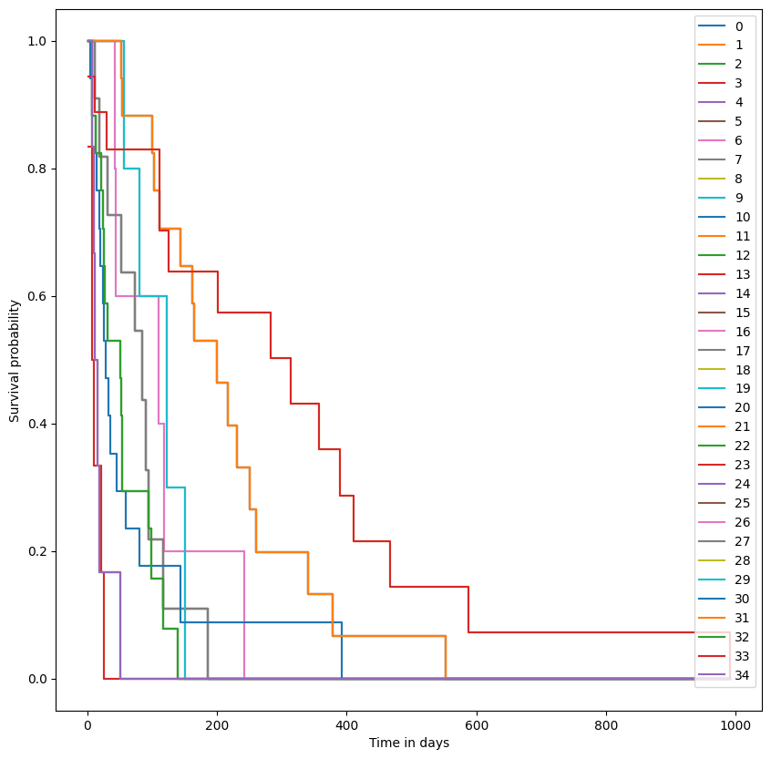

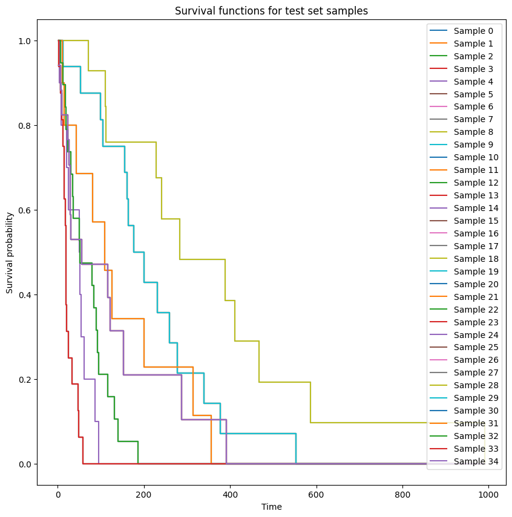

```python
survival_trees = survivalTree.predict_survival_function(x_test)
plt.figure(figsize=(10, 10))
for i, sf in enumerate(survival_trees):
    plt.step(sf.x, sf.y, where='post', label="Sample {}".format(i))
plt.xlabel("Time")
plt.ylabel("Survival probability")
plt.title("Survival functions for test set samples")
plt.legend()
plt.show()
```

## Task 5:

Convert the notebook into html:

1. Download the notebook by clicking the File tab
2. Upload it to this environment
3. Run the command:

```python
%%shell
jupyter nbconvert --to html Lab6.ipynb
```